# Homework 3

Coby Eshaghian

## Classification

For this assignment, we will be working with part of a [Kaggle data set](https://www.kaggle.com/c/titanic/overview) that was the subject of a machine learning competition and is often used for practicing ML models. The goal is classification; specifically, to predict which passengers would survive the [Titanic shipwreck](https://en.wikipedia.org/wiki/Titanic).

Load the data from `data/titanic.csv` into *R* and familiarize yourself with the variables it contains using the codebook (`data/titanic_codebook.txt`).

```r
library(tidyverse)
library(tidymodels)
library(ggplot2)
titanic <- read.csv('/Users/cobyeshaghian/Downloads/pstat 131/homework-3/data/titanic.csv')
head(titanic)
```

```
##   passenger_id survived pclass
## 1            1       No      3
## 2            2      Yes      1
## 3            3      Yes      3
## 4            4      Yes      1
## 5            5       No      3
## 6            6       No      3
##                                                  name    sex age sib_sp parch
## 1                             Braund, Mr. Owen Harris   male  22      1     0
## 2 Cumings, Mrs. John Bradley (Florence Briggs Thayer) female  38      1     0
## 3                              Heikkinen, Miss. Laina female  26      0     0
## 4        Futrelle, Mrs. Jacques Heath (Lily May Peel) female  35      1     0
## 5                            Allen, Mr. William Henry   male  35      0     0
## 6                                    Moran, Mr. James   male  NA      0     0
##             ticket    fare cabin embarked
## 1        A/5 21171  7.2500  <NA>        S
## 2         PC 17599 71.2833   C85        C
## 3 STON/O2. 3101282  7.9250  <NA>        S
## 4           113803 53.1000  C123        S
## 5           373450  8.0500  <NA>        S
## 6           330877  8.4583  <NA>        Q
```

Notice that `survived` and `pclass` should be changed to factors. When changing `survived` to a factor, you may want to reorder the factor so that *“Yes”* is the first level.

```r
titanic$surv <- ifelse(titanic$survived == 'Yes', 1, 0)

head(titanic)
```

```
##   passenger_id survived pclass
## 1            1       No      3
## 2            2      Yes      1
## 3            3      Yes      3
## 4            4      Yes      1
## 5            5       No      3
## 6            6       No      3
##                                                  name    sex age sib_sp parch
## 1                             Braund, Mr. Owen Harris   male  22      1     0
## 2 Cumings, Mrs. John Bradley (Florence Briggs Thayer) female  38      1     0
## 3                              Heikkinen, Miss. Laina female  26      0     0
## 4        Futrelle, Mrs. Jacques Heath (Lily May Peel) female  35      1     0
## 5                            Allen, Mr. William Henry   male  35      0     0
## 6                                    Moran, Mr. James   male  NA      0     0
##             ticket    fare cabin embarked surv
## 1        A/5 21171  7.2500  <NA>        S    0
## 2         PC 17599 71.2833   C85        C    1
## 3 STON/O2. 3101282  7.9250  <NA>        S    1
## 4           113803 53.1000  C123        S    1
## 5           373450  8.0500  <NA>        S    0
## 6           330877  8.4583  <NA>        Q    0
```

Make sure you load the `tidyverse` and `tidymodels`!

*Remember that you’ll need to set a seed at the beginning of the document to reproduce your results.*

### Question 1

Split the data, stratifying on the outcome variable, `survived.` You should choose the proportions to split the data into. Verify that the training and testing data sets have the appropriate number of observations. Take a look at the training data and note any potential issues, such as missing data.

Why is it a good idea to use stratified sampling for this data?

So that we can observe different subgroups all while they share the same statistic.

```r
set.seed(1999)

titanic_split <- initial_split(titanic, prop = 0.75,
                                strata = surv)
titanic_train <- training(titanic_split)
titanic_test <- testing(titanic_split)

print(titanic_train)
```

[output not shown]

[output cut: 2657 more lines]

### Question 2

Using the **training** data set, explore/describe the distribution of the outcome variable `survived`.

We see that it reorginizes the data such that survived so we can compare different outcomes between those who survived and who didn’t.

### Question 3

Using the **training** data set, create a correlation matrix of all continuous variables. Create a visualization of the matrix, and describe any patterns you see. Are any predictors correlated with each other? Which ones, and in which direction?

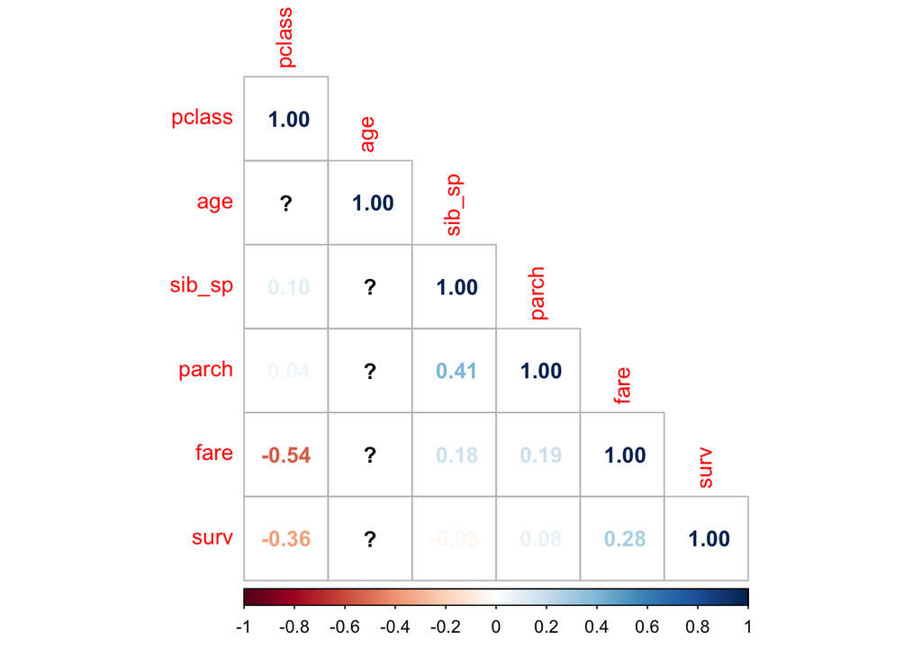

```r
library(corrplot)
numtitanic_train <- titanic_train[,sapply(titanic_train,is.numeric)] #remove non-numeric numbers
numtitanic_train$passenger_id <- NULL
corrplot(cor(numtitanic_train), method = 'number', type = 'lower') #normalize the data within correlation parameters [-1,1]
```

### Question 4

Using the **training** data, create a recipe predicting the outcome variable `survived`. Include the following predictors: ticket class, sex, age, number of siblings or spouses aboard, number of parents or children aboard, and passenger fare.

Recall that there were missing values for `age`. To deal with this, add an imputation step using `step_impute_linear()`. Next, use `step_dummy()` to **dummy** encode categorical predictors. Finally, include interactions between:

- Sex and passenger fare, and
- Age and passenger fare.

```r
titrec <- recipe(survived ~  pclass + sex + age + sib_sp + parch + fare, data = titanic_train) %>%
  step_dummy(all_nominal_predictors()) %>%
  step_center(all_numeric_predictors()) %>%
  step_scale((all_numeric_predictors())) %>%
  step_impute_linear(age)

intmod1 <- titrec %>%
  step_interact(terms = ~ sex:fare)

intmod1 <- prep(intmod1, training = titanic_train)

intmod2 <- titrec %>%
  step_interact(terms = ~ age:fare)

intmod2 <- prep(intmod2, training = titanic_train)
```

You’ll need to investigate the `tidymodels` documentation to find the appropriate step functions to use.

### Question 5

Specify a **logistic regression** model for classification using the `"glm"` engine. Then create a workflow. Add your model and the appropriate recipe. Finally, use `fit()` to apply your workflow to the **training** data.

*Hint: Make sure to store the results of `fit()`. You’ll need them later on.*

```r
log_model <- logistic_reg() %>%
  set_mode("classification") %>%
  set_engine("glm")

log_wflow <- workflow() %>%
  add_model(log_model) %>%
  add_recipe(titrec)

log_fit <- fit(log_wflow, titanic_train)
```

### Question 6

**Repeat Question 5**, but this time specify a linear discriminant analysis model for classification using the `"MASS"` engine.

```r
library(MASS)
library(discrim)


lda_mod <- discrim_linear() %>%
  set_mode("classification") %>%
  set_engine("MASS")

lda_wkflow <- workflow() %>%
  add_model(lda_mod) %>%
  add_recipe(titrec)

lda_fit <- fit(lda_wkflow, titanic_train)
```

### Question 7

**Repeat Question 5**, but this time specify a quadratic discriminant analysis model for classification using the `"MASS"` engine.

```r
qda_mod <- discrim_quad() %>%
  set_mode("classification") %>%
  set_engine("MASS")

qda_wkflow <- workflow() %>%
  add_model(qda_mod) %>%
  add_recipe(titrec)

qda_fit <- fit(qda_wkflow, titanic_train)
```

### Question 8

**Repeat Question 5**, but this time specify a naive Bayes model for classification using the `"klaR"` engine. Set the `usekernel` argument to `FALSE`.

```r
library(caret)
nb_mod <- naive_Bayes() %>%
  set_mode("classification") %>%
  set_engine("klaR") %>%
  set_args(usekernel = FALSE)

nb_wkflow <- workflow() %>%
  add_model(nb_mod) %>%
  add_recipe(titrec)

nb_fit <- fit(nb_wkflow, titanic_train)
```

### Question 9

Now you’ve fit four different models to your training data.

Use `predict()` and `bind_cols()` to generate predictions using each of these 4 models and your **training** data. Then use the *accuracy* metric to assess the performance of each of the four models.

```r
logpre <- predict(log_fit, new_data = titanic_train, type = "prob")

ldapre <- predict(lda_fit, new_data = titanic_train, type = "prob")

qdapre <- predict(qda_fit, new_data = titanic_train, type = "prob")

nbpre <- predict(nb_fit, new_data = titanic_train, type = "prob")

library("dplyr")

log_reg_acc <- augment(log_fit, new_data = titanic_train) %>%
  accuracy(truth = factor(survived), estimate = .pred_class)

lda_acc <- augment(lda_fit, new_data = titanic_train) %>%
  accuracy(truth = factor(survived), estimate = .pred_class)

qda_acc <- augment(qda_fit, new_data = titanic_train) %>%
  accuracy(truth = factor(survived), estimate = .pred_class)

nb_acc <- augment(nb_fit, new_data = titanic_train) %>%
  accuracy(truth = factor(survived), estimate = .pred_class)

accuracies <- c(log_reg_acc$.estimate, lda_acc$.estimate,
                nb_acc$.estimate, qda_acc$.estimate)
models <- c("Logistic Regression", "LDA", "Naive Bayes", "QDA")
results <- tibble(accuracies = accuracies, models = models)
results %>%
  arrange(-accuracies)
```

```
## # A tibble: 4 × 2
##   accuracies models
##        <dbl> <chr>
## 1      0.814 Logistic Regression
## 2      0.805 QDA
## 3      0.802 LDA
## 4      0.792 Naive Bayes
```

Which model achieved the highest accuracy on the training data?

**The logistic regression model had the highest accuracy on the training data.**

### Question 10

Fit the model with the highest training accuracy to the **testing** data. Report the accuracy of the model on the **testing** data.

Again using the **testing** data, create a confusion matrix and visualize it. Plot an ROC curve and calculate the area under it (AUC).

```r
lgtest_fit <- fit(log_wflow, titanic_test)

lgtest_acc <- augment(lgtest_fit, new_data = titanic_test) %>%
  accuracy(truth = factor(survived), estimate = .pred_class)
lgtest_acc
```

```
## # A tibble: 1 × 3
##   .metric  .estimator .estimate
##   <chr>    <chr>          <dbl>
## 1 accuracy binary         0.804
```

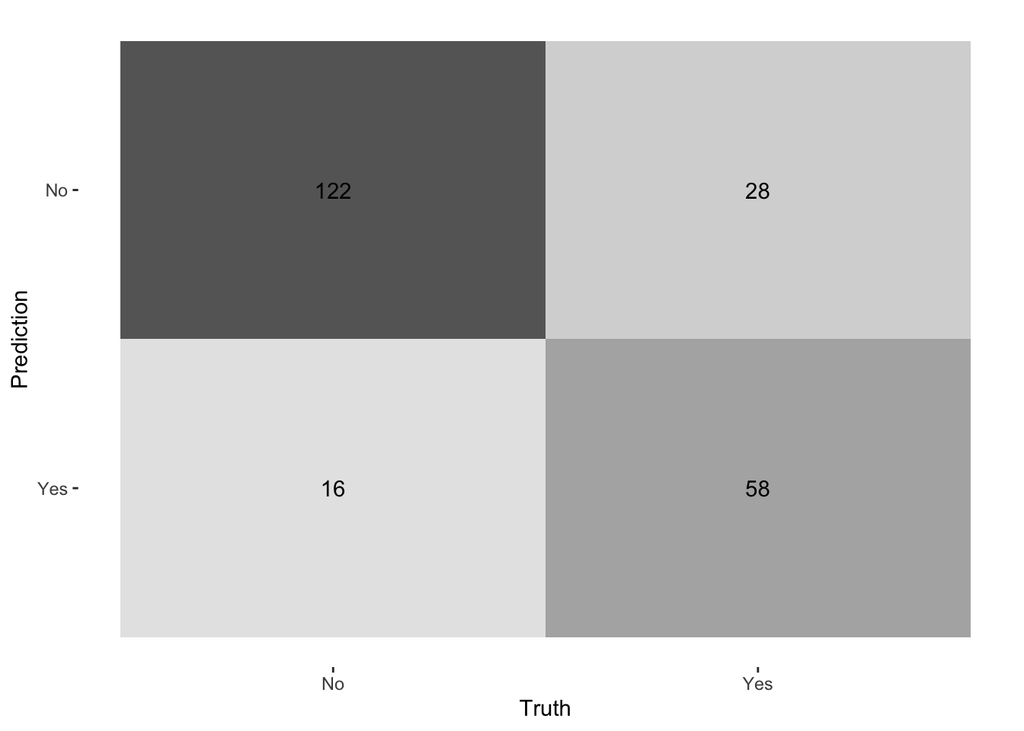

```r
augment(lgtest_fit, new_data = titanic_test) %>%
  conf_mat(truth = survived, estimate = .pred_class) %>%
  autoplot(type = "heatmap")
```

```r
#augment(lgtest_fit, new_data = titanic_test) %>%
  #roc_curve(truth = survived) %>%
  #autoplot()

#for some reason, code above isn't working. I reached out to hanmo to get resolved but wasn't able to find a time that worked for both of us...
```

How did the model perform? Compare its training and testing accuracies. If the values differ, why do you think this is so?